# PracticalMachineLearning_Prediction

andhdo

15 de noviembre de 2015

## Executive Summary

Has been collected measures about particular activity for a set of people, using sensors (fuelband,filbit,jawboneup) to collect its body activity. The goal is to predict the way in what they do excerciese using a machine learming model and examining 20 test cases. Data for this project comes from this souce (Chapter WLE): http://groupware.les.inf.puc-rio.br/har. That gives the dataset of recorded activity in a set of Weight Lifting Excercises. Variable “classe” is the indictor of the exercise that was made and the way it was done (varying the performance of the excercise from class A to E being A the right way to do it, and the next 4 are common mistakes in doing that). We can use the other variables of the dataset to predict it.

- Source Repo: https://github.com/andhdo/coursera_dsc_08_pml_project.git

## Exploratory Data Analysis

### Loading Data

Some initialization activities are made to load the dataset and libraries from the referenced url. In order to reproduce it, you need to install those packages in R using the install.packages command

```
## Versión 4.0.0 Copyright (c) 2006-2015 Togaware Pty Ltd.
## Escriba 'rattle()' para agitar, sacudir y  rotar sus datos.
```

trainRaw and testRaw contains the values of the loaded data. They have the following dimensions (rows: observations ,columns: variables)

```
## [1] 19622   160
```

```
## [1]  20 160
```

### Preprocess the Data

```r
# obs with complete data:
sum(complete.cases(trainRaw))
```

```
## [1] 406
```

```r
# remove NA's
trainRaw <- trainRaw[, colSums(is.na(trainRaw)) == 0]
testRaw <- testRaw[, colSums(is.na(testRaw)) == 0]

# remove variables not related with accelerometer
# so that it does not interfer with the ML algorithms
# then set back the dataset
classe <- trainRaw$classe
trainRemove <- grepl("^X|timestamp|window",names(trainRaw))
trainRaw <- trainRaw[, !trainRemove]
trainCleaned <- trainRaw[, sapply(trainRaw, is.numeric)]
trainCleaned$classe <- classe
testRemove <- grepl("^X|timestamp|window",names(testRaw))
testRaw <- testRaw[, !testRemove]
testCleaned <- testRaw[, sapply(testRaw, is.numeric)]
dim(trainCleaned)
```

```
## [1] 19622    53
```

### Split the data

We split the trainging dataset (70% for pure trainign and 30% of the data to conduct cross vallidation)

```r
set.seed(22519) # For reproducibile purpose
inTrain <- createDataPartition(trainCleaned$classe, p=0.70,list=F)
trainData <- trainCleaned[inTrain, ]
testData <- trainCleaned[-inTrain, ]
```

## Model Analysis: Using RandomForest

We use RandomForest because it select automatically correlated variables. We use 5 folds cross validation. To build the model we use ‘classe’ variable as target preditor and the other ones as covariates

```r
controlRf <- trainControl(method="cv", 5)
modelRf <- train(classe ~ ., data=trainData, method="rf",trControl=controlRf, ntree=250)
modelRf
```

```
## Random Forest
##
## 13737 samples
##    52 predictor
##     5 classes: 'A', 'B', 'C', 'D', 'E'
##
## No pre-processing
## Resampling: Cross-Validated (5 fold)
## Summary of sample sizes: 10989, 10989, 10991, 10990, 10989
## Resampling results across tuning parameters:
##
##   mtry  Accuracy   Kappa      Accuracy SD  Kappa SD
##    2    0.9910462  0.9886729  0.001301269  0.001647776
##   27    0.9914102  0.9891334  0.001717547  0.002174708
##   52    0.9850037  0.9810264  0.002718384  0.003439965
##
## Accuracy was used to select the optimal model using  the largest value.
## The final value used for the model was mtry = 27.
```

Then, we estimate the performance of the model on the validation data set.

```r
predictRf <- predict(modelRf, testData)
confusionMatrix(testData$classe, predictRf)
```

```
## Confusion Matrix and Statistics
##
##           Reference
## Prediction    A    B    C    D    E
##          A 1672    1    0    0    1
##          B    7 1128    4    0    0
##          C    0    0 1021    5    0
##          D    0    0   14  949    1
##          E    0    0    1    7 1074
##
## Overall Statistics
##
##                Accuracy : 0.993
##                  95% CI : (0.9906, 0.995)
##     No Information Rate : 0.2853
##     P-Value [Acc > NIR] : < 2.2e-16
##
##                   Kappa : 0.9912
##  Mcnemar's Test P-Value : NA
##
## Statistics by Class:
##
##                      Class: A Class: B Class: C Class: D Class: E
## Sensitivity            0.9958   0.9991   0.9817   0.9875   0.9981
## Specificity            0.9995   0.9977   0.9990   0.9970   0.9983
## Pos Pred Value         0.9988   0.9903   0.9951   0.9844   0.9926
## Neg Pred Value         0.9983   0.9998   0.9961   0.9976   0.9996
## Prevalence             0.2853   0.1918   0.1767   0.1633   0.1828
## Detection Rate         0.2841   0.1917   0.1735   0.1613   0.1825
## Detection Prevalence   0.2845   0.1935   0.1743   0.1638   0.1839
## Balanced Accuracy      0.9977   0.9984   0.9903   0.9922   0.9982
```

```r
accuracy <- postResample(predictRf, testData$classe)
accuracy
```

```
##  Accuracy     Kappa
## 0.9930331 0.9911872
```

```r
oose <- 1 - as.numeric(confusionMatrix(testData$classe, predictRf)$overall[1])
oose
```

```
## [1] 0.006966865
```

So, the estimated accuracy of the model is 99.3% and the estimated out-of-sample error is 0.69%.

## Model Usage: Predicting for TestData

Now the model is applied to the downloaded testing dataset and print the result (for the 20 different test cases)

```r
result <- predict(modelRf, testCleaned[, -length(names(testCleaned))])
result
```

```
##  [1] B A B A A E D B A A B C B A E E A B B B
## Levels: A B C D E
```

## Appendix: Figures

- Correlation matrix

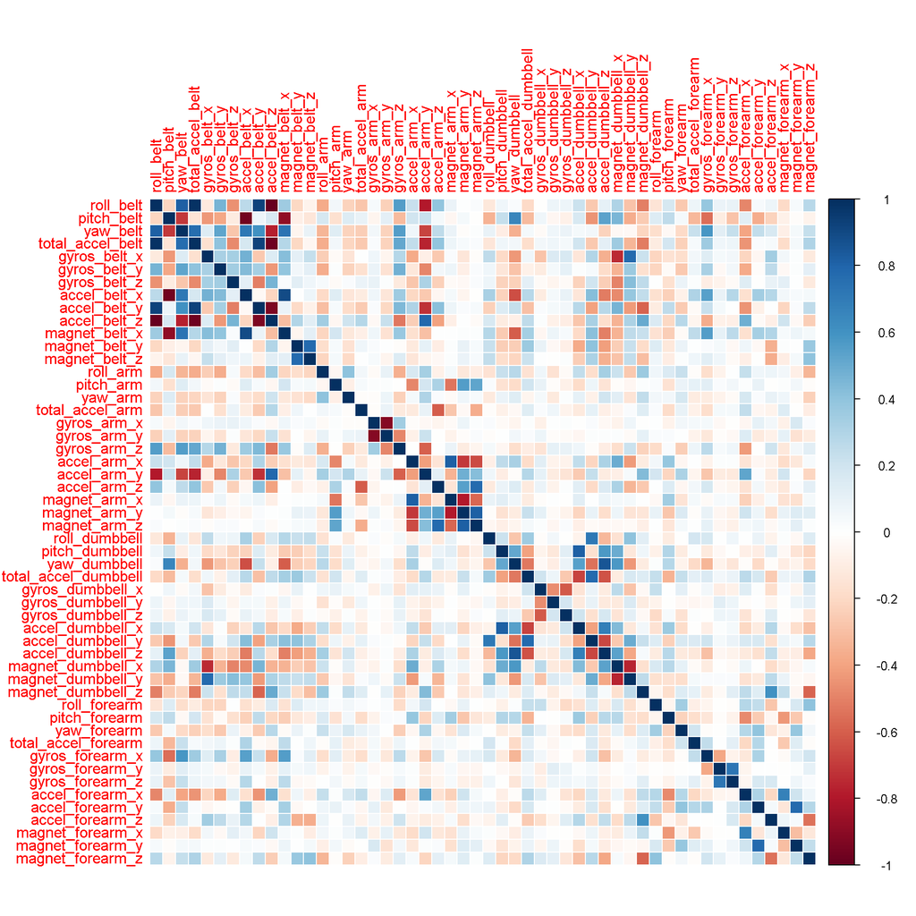

```r
corrPlot <- cor(trainData[, -length(names(trainData))])
corrplot(corrPlot, method="color")
```

- Decision Tree (1)

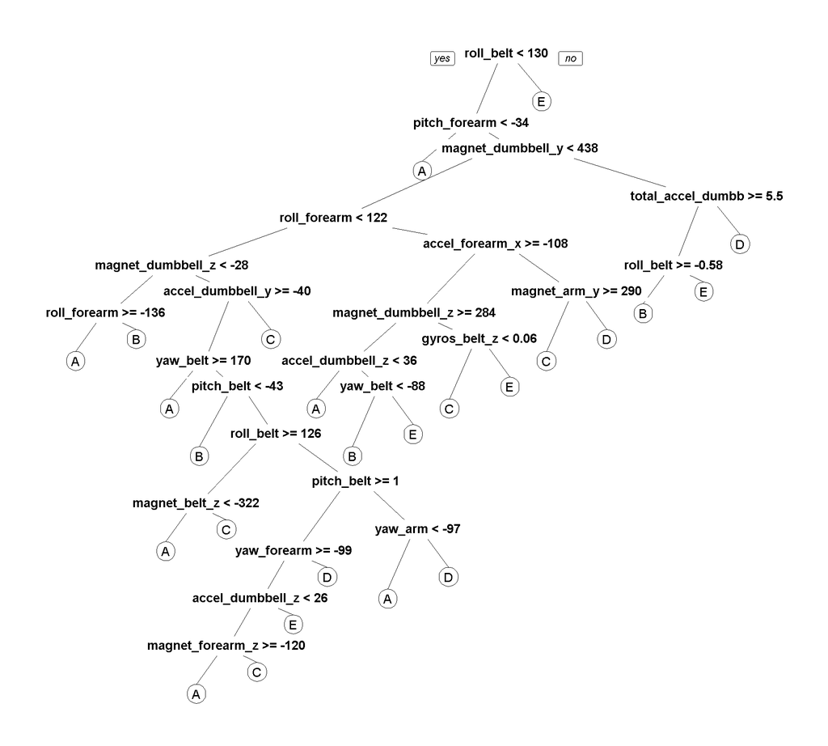

```r
treeModel <- rpart(classe ~ ., data=trainData, method="class")
prp(treeModel) # fast plot
```

- Decision Tree (2)

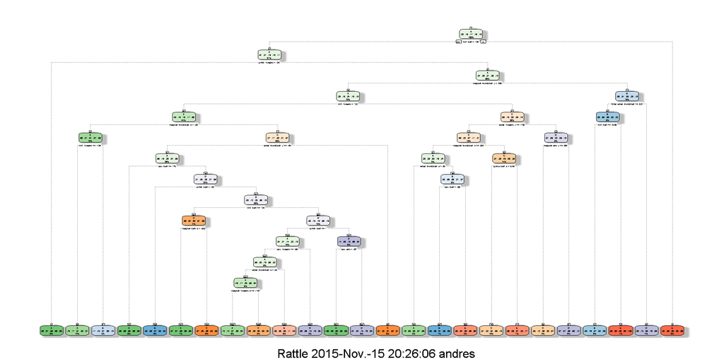

```r
fancyRpartPlot(treeModel)
```